# Analiza danych z CNK z maja 2012

Przemysław Dycha, Magda Sobiczewska, Krzysztof Smutek, Piotr Weremczuk

27 kwiecień 2016

# Faza I

## Wprowadzenie

Na samym początku chcemy zbadać podstawowe statystyki dotyczące eksponatów: - liczba odwiedzających w poszczególnych dniach tygodnia - liczba odwiedzających w zależności od godziny odwiedzin - czas spędzony na interakcje z eksponatem - liczba odwiedzin pojedynczych stacji - średni czas spędzony na danej stacji

## Obróbka danych i metody pracy

W poniższej analizie organiczyliśmy się do danych z maja. Z powodu ograniczonych możliwości obliczeniowych. Wyrzuciliśmy również użytkowników oznaczonych -1 oraz inne rekordy zapisane z błędem lub bez niektórych wartości. Pozbyliśmy się również tych, które wydawały nam się w jakimś sensie błędne, na przykład odwiedzających, którzy spędzili na poszczególnych eksponatach więcej niż godzinę. Do otrzymania statystyk użyliśmy wbudowanych narzędzi R oraz biblioteki sqldf i zapytań w języku SQL.

## Otrzymane wyniki

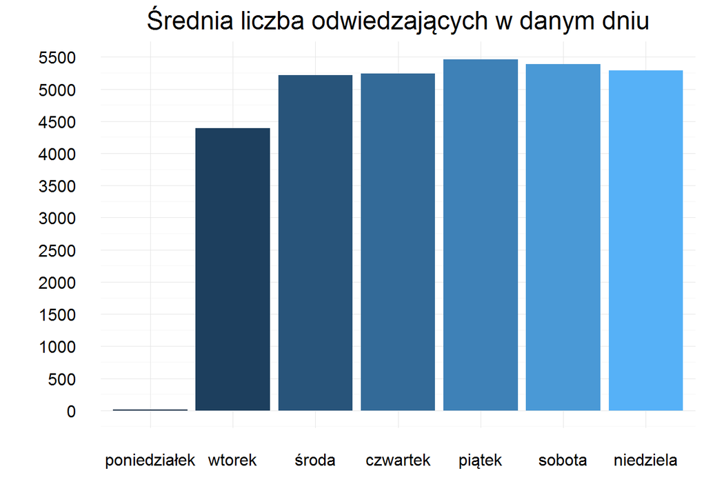

Zauważamy, że w poniedziałek liczba odwiedzjących jest bliska 0. Wynika to z faktu, że CNK w tym dniu jest zamknięte. Pomimo tego można zauważyć znikome interakcje, gdyż są wykonywane prace konserwacyjne na eksponatach. Ponadto liczba odwiedzających w poszczególne dni jest zbliżona. Na mniejszą liczbę we wtorek od pozostałych dni miał najprawdopodobniej wpływ 1 maja, który w 2012 roku wypadał właśnie we wtorek. Warto również zauważyć, że w piątki i soboty odwiedzających jest średnio nieco więcej w porównaniu do innych dni. Zapewne wynika to z faktu, iż są to pierwsze dni weekendu.

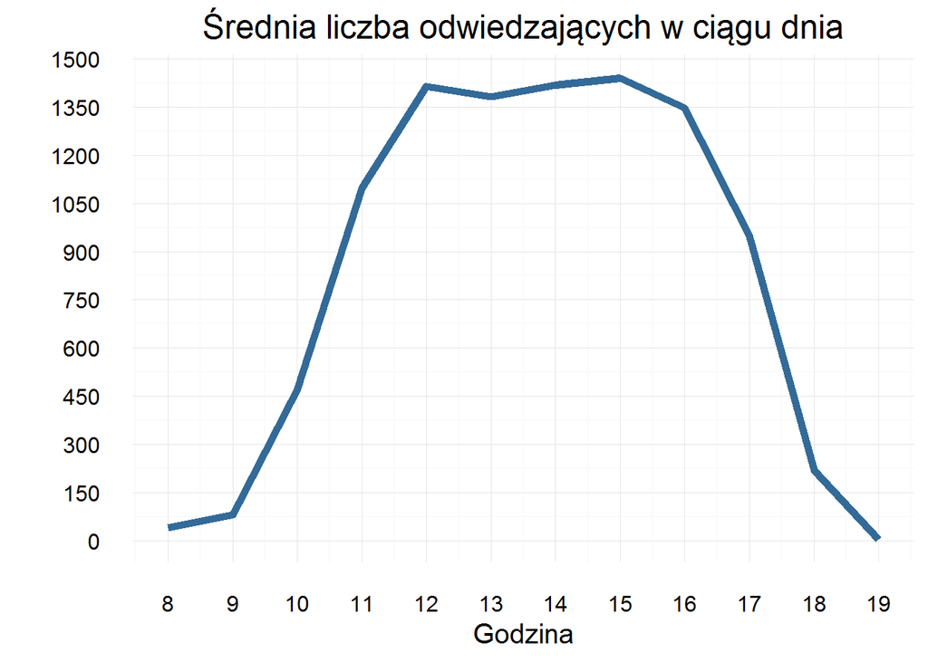

Zauważamy, że największa liczba odwiedzających centrum jest w godzinach 12-16. W późniejszych i wcześniejszych godzinach aktywność jest dużo mniejsza. Może być to przydatna informacja dla osób, które chcą spokojnie zwiedzić Centrum.

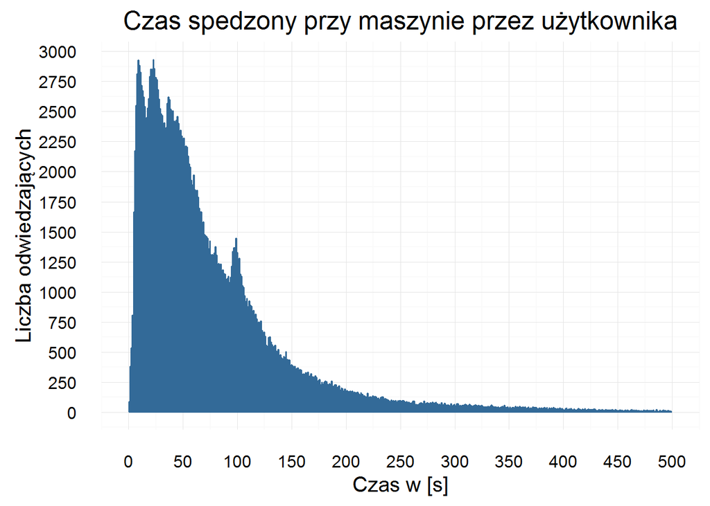

Rozkład czasu spędzonego przy maszynie wydaje się być zbliżony do rozkładu gamma. Widać jednak, że w okolicach 100 sekund następuje znaczny skok liczby odwiedzających. Zaintrygowani tym faktem zbadaliśmy, przy których maszynach odwiedzający spędzali między 95, a 105 sekund. Poniższa tabelka pokazuje najczęściej pojawiające się przypadki.

```
##   station liczba
## 1   cnk17   2608
## 2   cnk66    593
## 3   cnk20    569
## 4   cnk07    512
## 5   cnk67    496
## 6   cnk09    300
```

Można zauważyć, że za tę nieregularność w rozkładzie czasu spędzonego przy maszynie odpowiada stanowisko Otwartość na doświadczenie - cnk17. Zapewne skorzystanie z tej maszyny polega na przejściu przez pewien proses, który zajmuje około 100 sekund.

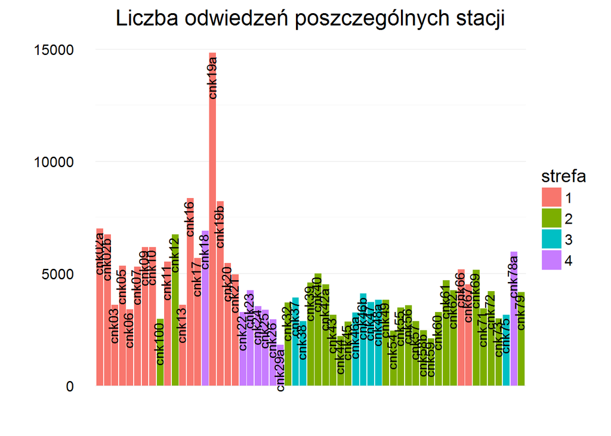

Zauważamy, że najbardziej odwiedzaną stacją było Wejście do sali strachów - cnk19a oraz Wyjście z sali strachów - cnk19b (jest to zapewne jeden eksponat rozbijający moment wejścia i wyjścia na osobne eksponaty). Ciekawe jest, że liczba przejść przez Wejście do sali strachów jest prawie dwukrotnie większa od liczby przejść przez Wyjście z sali strachów, co może sugerować, że wielu odwiedzających ze strachu rezygnowało z przejścia całej sali. Innymi często odwiedzanymi eksponatami są Powąchaj mnie - cnk16, Mózg podczas pracy - cnk02 oraz Kim jesteś - cnk18. Najmniej odwiedzanym eksponatem był Robot portrecista - cnk29a, dla którego niska liczba odwiedzających spowodowana była zapewne długim czasem spędzanym przy eksponacie (patrz następny wykres).

Ponadto dokonaliśmy podziału na stacje tematyczne cnk w sposób następujący

- Strefa 1: JA
- Strefa 2: JA - MY - ONI
- Strefa 3: JA - ŚWIAT
- Strefa 4: JA - TY

Można zauważyć, że zdecydowanie najwięcej odwiedzin było w grupie JA. Większość maszyn z tej grupy przekracza liczbę 5000 odwiedzeń czego nie można powiedzieć o innych grupach.

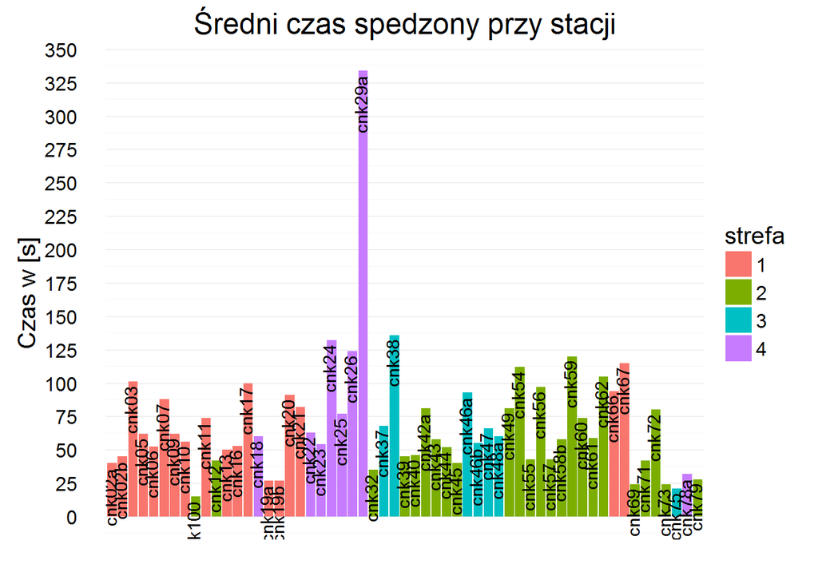

Tak jak pisaliśmy wcześniej stacja Robot portrecista - cnk29a miała największy czas spędzany na eksponacie. Niewielka liczba odwiedzających wynika z tego, że jest ona bardzo często zajęta. Być może warto byłoby utworzyć nowy eksponat o podobnej charakterystyce. Warto też zwrócić uwagę na stację Otwartość na doświadczenie - cnk17, przy której rzeczywiście spędzano średnio około 100 sekund co potwierdza nasze wcześniejsze obserwacje. Porównując oba powyższe wykresy można pokusić się o wstępne wybranie najmniej popularnych maszyn. Będą to te, dla których liczba odwiedzeń jest mała jak i średni czas spędzony przy maszynie jest niski.

## Podsumowanie fazy I

Zauważyliśmy, że czasy interakcji z eksponatami są w większości przypadków krótkie. W poszczególne dni tygodnia średnia liczba odwiedzin jest podobna. Natomiast liczba odwiedzin Centrum jest najwyższa we wczesnych godzinach popołudniowych.

Udało nam się zbadać niektóre statystyki dotyczące maszyn i dzięki temu wyłapaliśmy charakterystyczne stacje. Stworzyliśmy wstępną ocenę popularności eksponatów.

# Faza II i III - analiza segmentów

## Wprowadzenie

W drugim etapie postaramy się zbadać, czy dane dzielą się na jakieś charakterystyczne podgrupy.

Postaramy się odpowiedzieć na następujące pytania:

- Czy istnieje jakiś charakterystyczny podział stacji ze względu na liczbę odwiedzin i średni czas interakcji ?
- Jak wygląda zależność między liczbą interakcji użytkownika, a czasem spędzonym na stacjach ?
- Jak wygląda podział ze względu na liczbe odwiedzonych stacji i czas spędzony na stacjach ?
- Czy można wyodrębnić charakterystyczne grupy zwiedzających i stacji ?
- Wreszcie, jakie są związki otrzymanych w ten sposób klastrów z podziałem na strefy ?

## Uzyskane rezulaty

### Średni czas, a liczba odwiedzin

Zastosowane metody:

W związku z dużą liczbą danych, odwiedzający zostali podzieleni na podstawie algorytmu kmeans. Ograniczenia pamięciowe nie pozwoliły na policzenie potrzebnych odległości w inny sposób. Dokonaliśmy również podziału na sesje, który wyróżnia odwiedzającego powracającego do eksponatu po pewnym czasie.

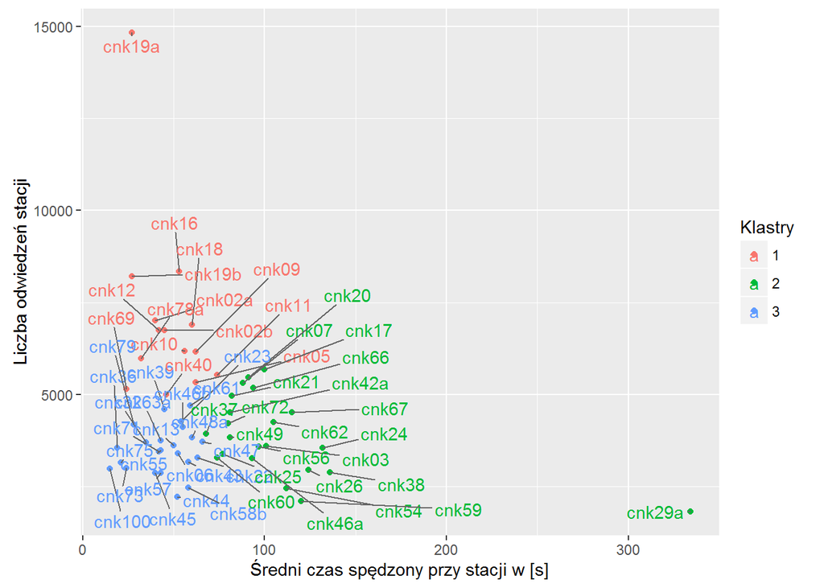

Na tym wykresie widać podział stacji na trzy grupy w zależności od czasu oraz liczby odwiedzin. Liczba grup jest dobrana eksperymentalnie. Większa liczba grup nie wnosiła wiele do naszego podziału. Pierwsza grupa charakteryzuje się dużą liczbą odwiedzin i krótkim czasem interakcji. W drugiej grupie znajdują się eksponaty, dla których średni czas interakcji jest długi, natomiast liczba odwiedzin mała. W ostatniej grupie znalazły się mało popularne eksponaty dla których mamy niewielką liczbę odwiedzin oraz krótki czas interakcji. Potwierdzają to: tabelka z centrami grup i boxploty.

```
##    station numberOfVisitors mediantime
## 2   cnk02b             6741         45
## 43   cnk56             3581         97
## 42   cnk55             3479         43
```

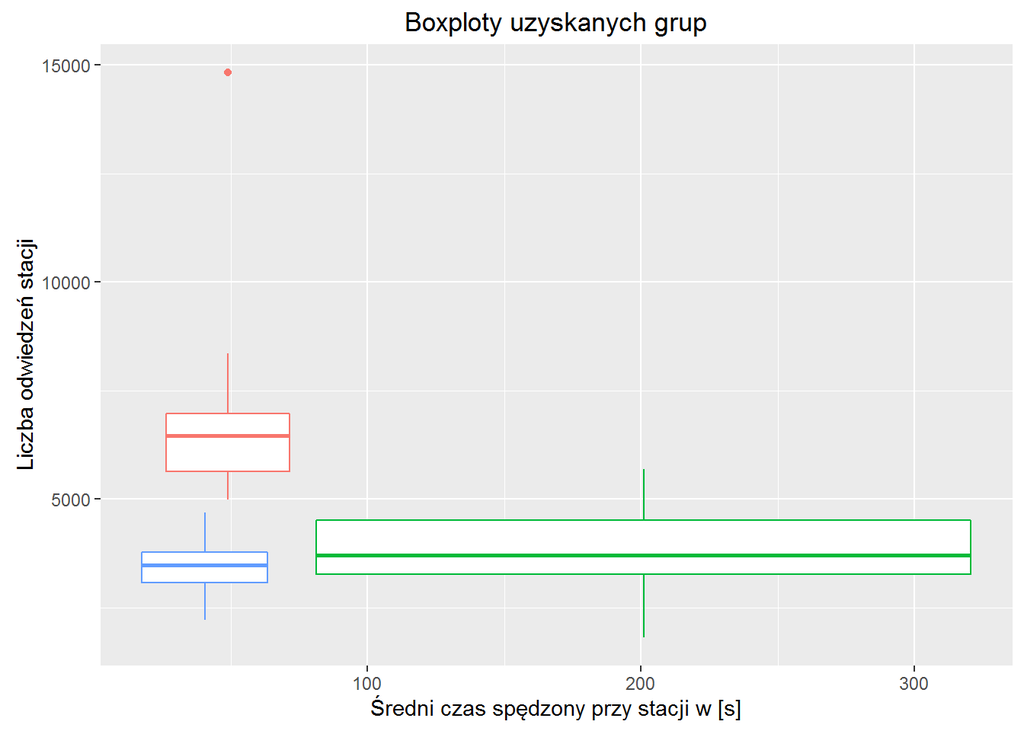

Przywołując wykres z podziałami tematycznymi zauważamy, że grupę czerwoną (krótki czas, duża liczba odwiedzin) tworzą przede wszystkim eksponaty z kategorii JA. Potwierdza to zauważone na wcześniejszych wykresach zależności.

### Podział ze względu na liczbę odwiedzonych stacji

Na samym początku utworzyliśmy macierz w której zawarte są informacje dotyczące odwiedzającego. Dokładniej:

- liczba wejść na danej stacji przez odwiedzającego
- łączna liczba czynności na wszystkich eksponatach
- średni czas spędzony na wszystkich odwiedzonych stacjach
- liczba odwiedzonych stacji

Korzystając z tej charakteryzacji dokonaliśmy dwóch podziałów: zależności czasu spędzonego od liczby interakcji oraz liczby odwiedzonych stacji w zależności od średniego czasu spędzonego na stacji. Poniżej przedstawiamy fragment macierzy oraz uzyskane rezultaty:

```
##   visitor cnk02a cnk78a cnk79 liczbainterakcji sredniczas liczbastacji
## 1 1043614      0      0     0               15  110.00000            3
## 2 1043616      0      0     0                1   14.00000            1
## 3 1043617      0      0     0               34  250.75000            3
## 4 1043631      0      0     0               38   62.75000            8
## 5 1043636      4      0     3              141   93.20833           25
## 6 1043637      0      0     3               53  197.20000            5
```

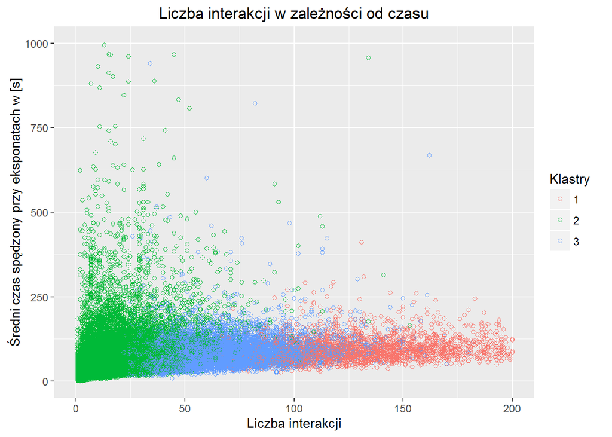

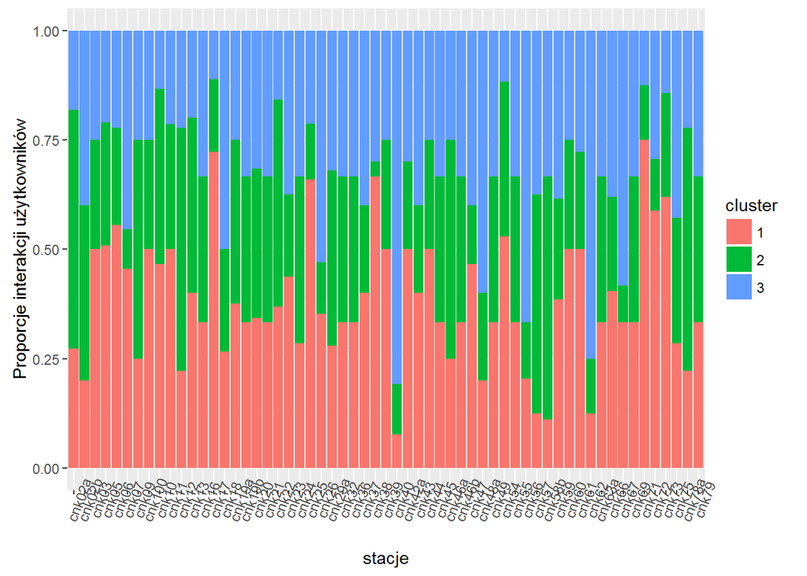

Wykres przedstawia proporcje interakcji pochodzących z każdej grup, w zależności od stacji. Większość stacji zachowuje się bardzo podobnie. Można jednak zauważyć dwie charaktarystyczne skupiska:

- grupy w których liczba krótkich interakcji przekracza ponad 50% wszystkich
- grupy w których liczba krótkich interakcji jest znikoma w stosunku do całości

Z powodu sporej ilości stacji trudno jest odczytać konkretne nazwy. W związku z tym podzielimy je na 4 grupy, zgodnie z podziałem tematycznym CNK.

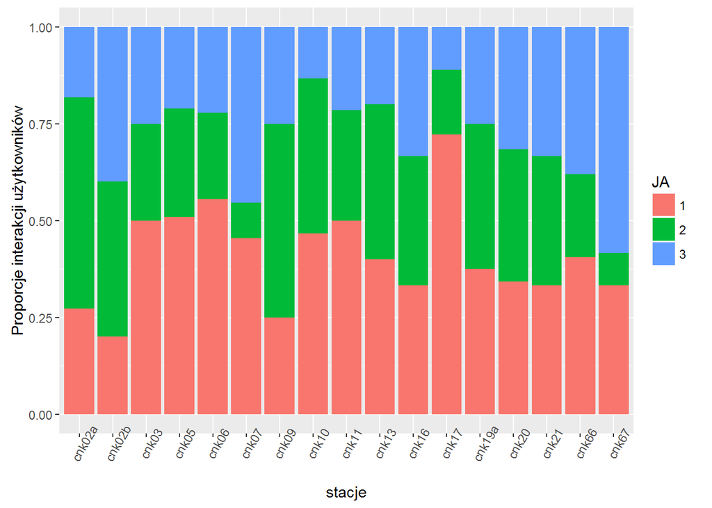

Widzimy, że na stacjach: cnk02a, cnk02b - Mózg podczas pracy oraz cnk09 - Sztuka i emocje przeważa grupa odwiedzających charakteryzująca się małą ilością interakcji. W przeciwieństwie do stacji cnk17 - Otwartość na doświadczenie, gdzie ponad połowa interakcji pochodzi od zwiedzających wykonujących dużo czynności.

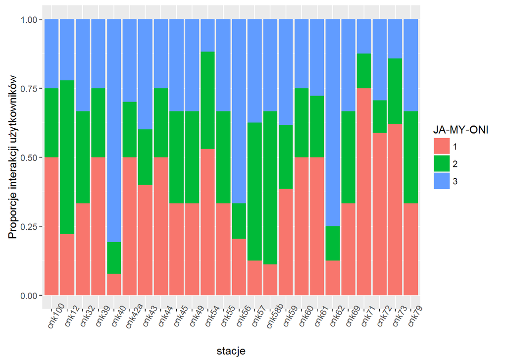

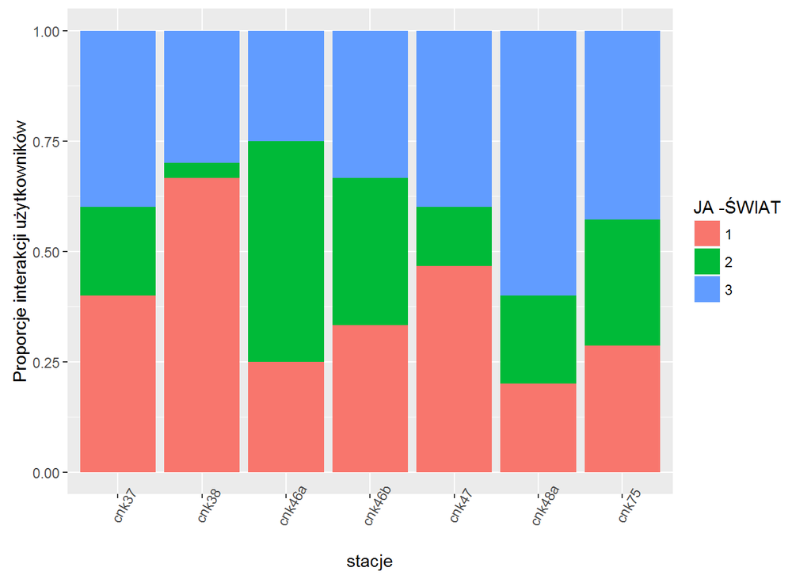

W grupie JA-ŚWIAT szczególną stacją jest cnk38 - Ile ziem. Ta stacja ma najmniej krótkich interakcji spośród wszystkich stacji.

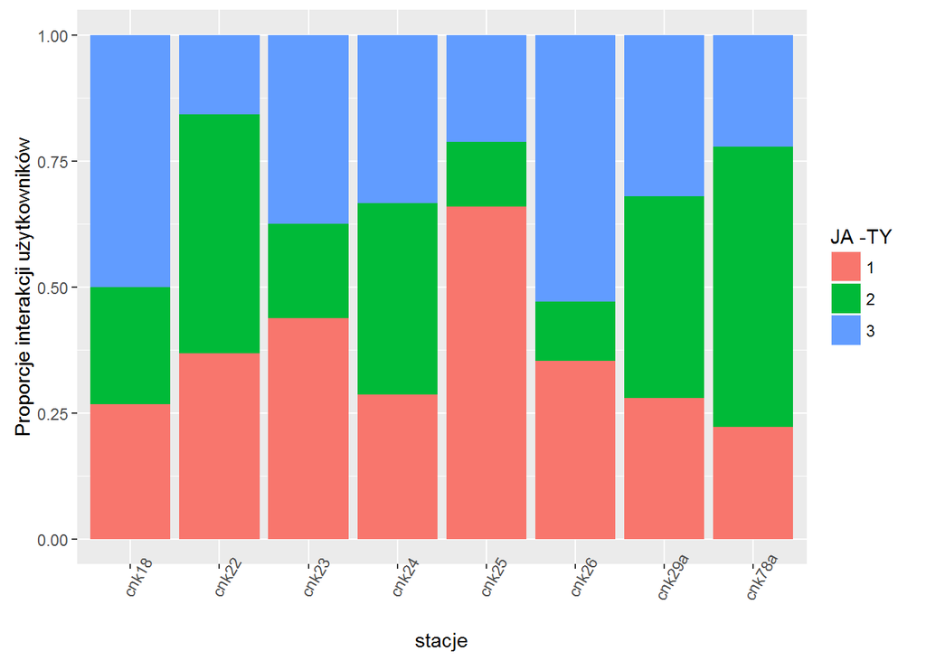

Tutaj szczególną stacją jest stacja cnk78a - Gadka szmatka, na której przeważają odwiedziny z niewielką liczbą interakcji.

Spróbujemy teraz podzielić odwiedzających na grupy w zależności od liczby odwiedzonych eksponatów i średniego czasu spędzonego na stacjach.

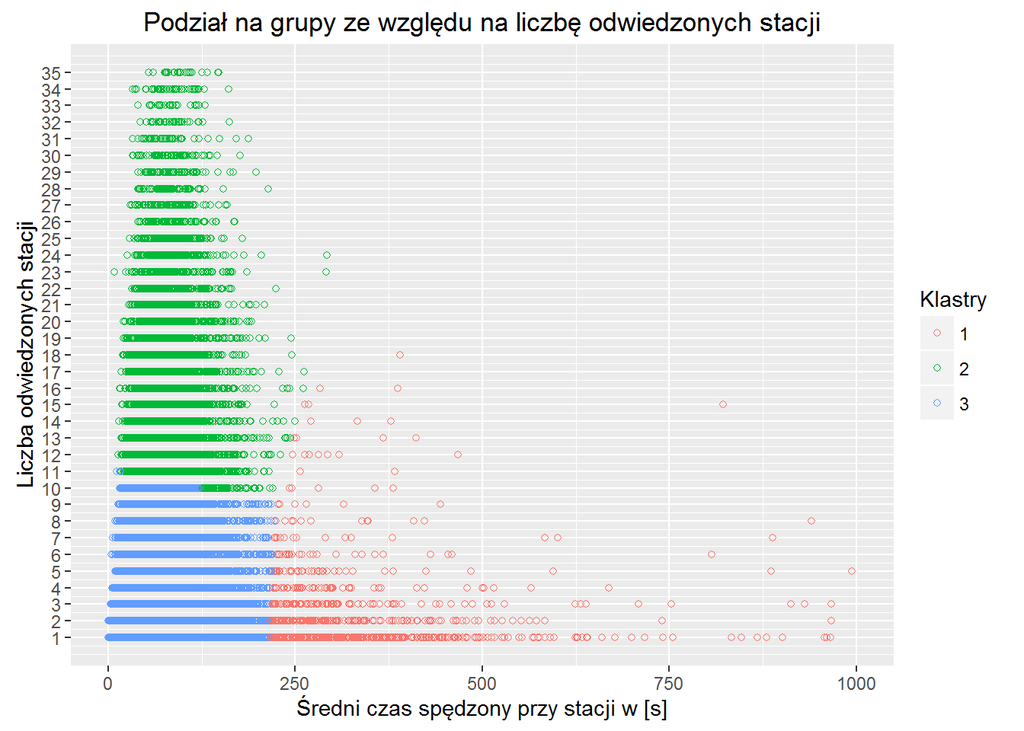

```
##   cluster count(*)
## 1       1      811
## 2       2     9303
## 3       3    26393
```

Do podziału wykorzystaliśmy klasteryzację z algorytmu kmeans. Utworzyliśmy 3 klastry. Wykres jest ucięty na poziomie 35 odwiedzin z racji kwesti wizualnych. Patrząc na wykres oraz statystyki zauważamy: - grupę w której znajdują się osoby odwiedzające niewielką liczbę eksponatów i spędzające na nich niewielką ilość czasu - grupę, w której znajdują się osoby które spędziły więcej czasu na poszczególnych eksponatach - grupę przedstawiającą osoby które odwiedziły dużą liczbę eksponatów

### Reguły odwiedzin

Odpowiemy na pytania:

- Czy istnieją eksponaty które wpływają na zwiększoną liczbę odwiedzin eksponatów sąsiednich ?
- Czy, oraz w jaki sposób, położenie stacji ma wpływ na jej odwiedziny ?

W tym celu będziemy korzystać z reguł asocjacyjnych.

[output not shown]

```
##    lhs                rhs      support   confidence lift
## 1  {cnk19b}        => {cnk19a} 0.3940553 0.9802343  1.694507
## 25 {cnk16,cnk19b}  => {cnk19a} 0.2162056 0.9848079  1.702413
## 24 {cnk12,cnk19b}  => {cnk19a} 0.1746125 0.9823400  1.698147
## 23 {cnk18,cnk19b}  => {cnk19a} 0.1574456 0.9768716  1.688694
## 22 {cnk19b,cnk78a} => {cnk19a} 0.1534236 0.9775000  1.689780
## 21 {cnk09,cnk19b}  => {cnk19a} 0.1516578 0.9822109  1.697924
```

[output not shown]

```
##     items           support
## 400 {cnk19a,cnk19b} 0.3940553
## 406 {cnk16,cnk19a}  0.3097901
## 405 {cnk12,cnk16}   0.2519129
## 404 {cnk12,cnk19a}  0.2499510
## 393 {cnk18,cnk19a}  0.2302335
## 372 {cnk09,cnk16}   0.2256229
```

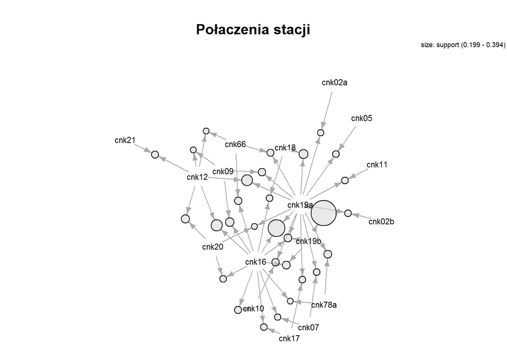

Widzimy, że zdecydowana większość połączeń ma związek ze stacją cnk19a, która miała największą liczbę odwiedzających. Zaburza to obraz połączeń i utrudnia dostrzeżenie ciekawych zależności. W związku z tym zobaczymy sytuację ponownie, z pominięciem stacji cnk19a.

[output not shown]

```
##     items          support
## 297 {cnk12,cnk16}  0.2519129
## 291 {cnk09,cnk16}  0.2256229
## 196 {cnk12,cnk20}  0.2231705
## 276 {cnk16,cnk19b} 0.2195409
## 258 {cnk16,cnk66}  0.2150284
## 268 {cnk10,cnk16}  0.2121836
```

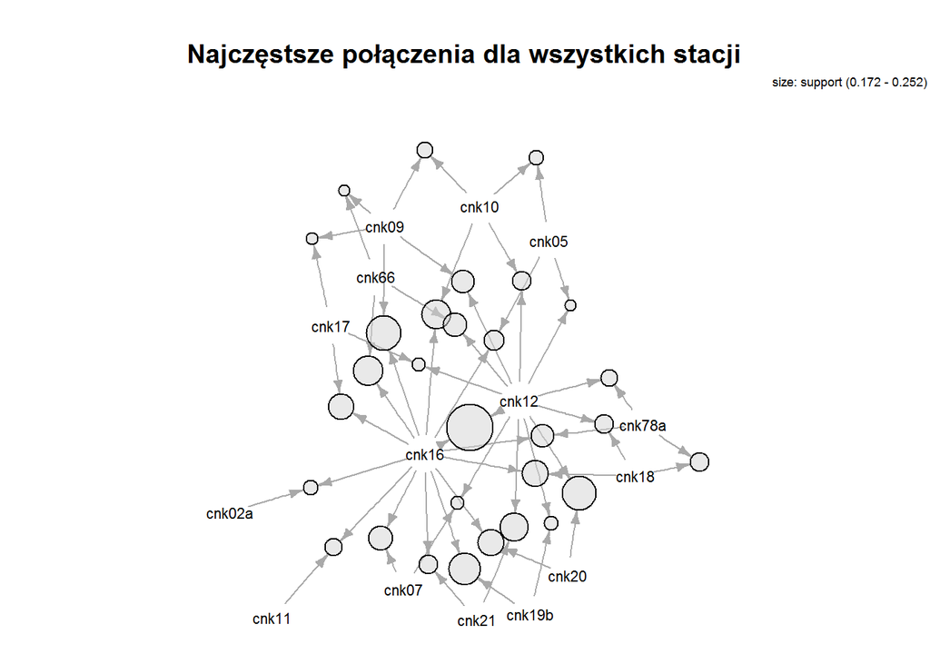

[output not shown]

```
##    items               support
## 22 {cnk12,cnk16,cnk20} 0.1420443
## 9  {cnk12,cnk16,cnk21} 0.1340004
## 47 {cnk12,cnk16,cnk66} 0.1330194
## 58 {cnk09,cnk12,cnk16} 0.1326270
## 50 {cnk10,cnk12,cnk16} 0.1236021
## 2  {cnk12,cnk20,cnk21} 0.1221307
```

[figure not shown]

Warto jeszcze zauważyć fakt, że stacja cnk16 jest stacją zachęcającą do odwiedzenia innych stacji. Osoby odwiedzające tę stację chętniej zaglądają do stacji blisko przy niej położonych.

### Grupowanie stacji i odwiedzajacych

Celem tej części jest wyodrębnienie - grup stacji - grup odwiedzających W oparciu o macierz odwiedzin, która na pozycji i,j ma jedynkę jeżeli i-ty gość zwiedził j-ty eksponat (zero w przeciwnym przypadku).

### Odległość JACCARDA

Postanowiliśmy wykorzystać odległość jaccarda ponieważ ma ona w naszej sytuacji naturalną interpretację: - jak dużo jest gości którzy zwiedzili obie wybrane stacje, w stosunku do liczby tych, którzy odwiedzili przynajmniej jedną.

Aby przedstawić sytuację wizualnie rzutujemy nasze wyniki na przestrzeń dwu-wymiarową. Ponieważ rzutowanie metryczne nie bylo zadowalajace (wartość ‘stess’ > 0.2 dla funkcji sammon{MASS}) postanowilismy skorzystać z altenratynego podejscia nie-metrycznyego: isoMDS{MASS} ( ’stress" ~ 0.13). Wykorzystanie metody PCA w naszym badaniu było wykluczone ponieważ stosowne odległości nie były oparte na metryce euklidesowej.

Do klastrowania wykorzystaliśmy metodę pam aby ułatwic interpretację wyników. Dla k=4 dostajemy 3 duże klastry i jeden 2 elementowy.

```
##   x freq
## 1 1   22
## 2 2   14
## 3 3    2
## 4 4   21
```

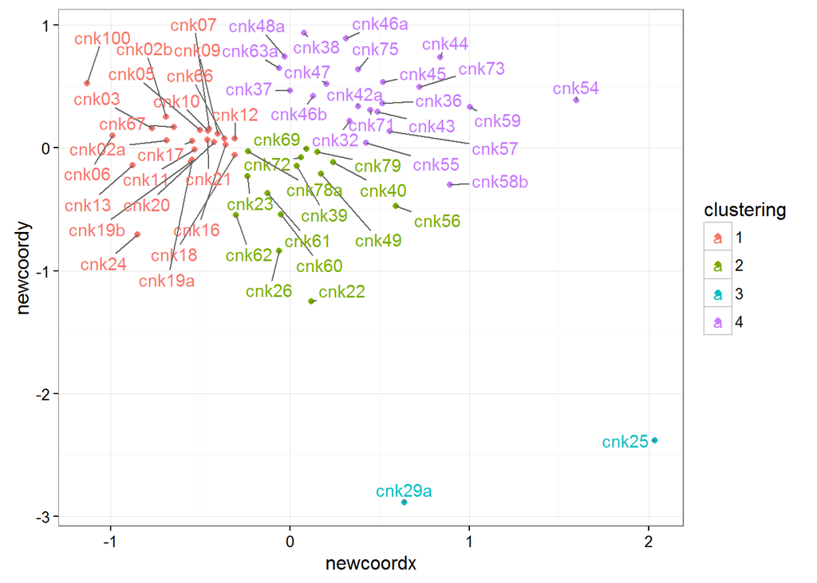

```
##               [,1]        [,2]
## cnk17  -0.54609163  0.05568454
## cnk39   0.03767116 -0.14832963
## cnk29a  0.63767724 -2.88612321
## cnk42a  0.37969445  0.33543885
```

Niestety wybór rzutowania ogranicza możliwość interpretacji odległości pojawiających się na wykresach. Można jedynie stwierdzić, że odległości odczytywane z wykresu możliwie najlepiej odpowiadają wyjściowym. Co ciekawe klaster położony w lewym górnym rogu w zdecydowanej większości składa się z eksponatów znajdujących się tuż przy wejściu co więcej klaster ten najmocniej spośród wszystkich utrzymywał się przy zmianie liczby klastrów. Jest to grupa eksponatów wyróżniająca się właściwie na każdym etapie badania.

Powyższą analizę dla porównania przedstawiamy również dla 7 klastrów.

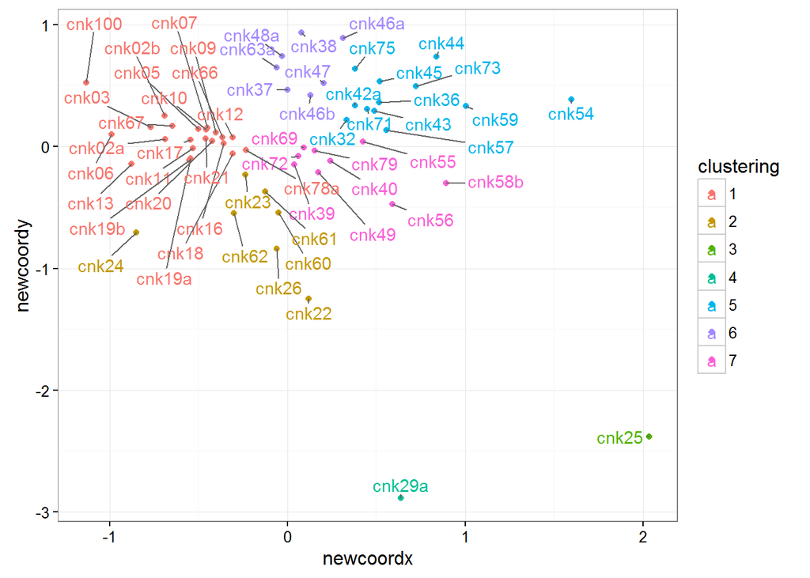

```
##               [,1]        [,2]
## cnk21  -0.46172621  0.06578496
## cnk62  -0.30074719 -0.54737393
## cnk25   2.03357214 -2.38125925
## cnk29a  0.63767724 -2.88612321
## cnk36   0.51692834  0.36119652
## cnk63a -0.06230261  0.64695676
## cnk40   0.24141964 -0.11727329
```

### Odległość MANHATTAN

Interpretacja tej odległości dla dwóch stacji A,B to: -liczba gości ktorzy odwiedzili dokładnie jedną stacje spośród A i B.

```
##   x freq
## 1 1    8
## 2 2   10
## 3 3   39
## 4 4    2
```

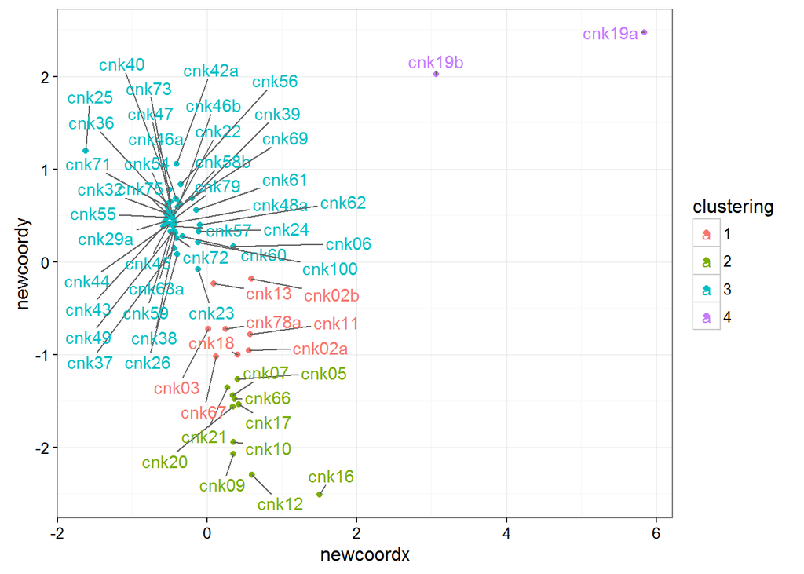

#### Klastrowanie na wizytorach

Po przeprowadzeniu wstępnych badań uznaliśmy, że należy ograniczyć analizę do odwiedzających o stosunkow dużej liczbie obejrzanych stacji. Brak tej restrykcji prowadził do sytuacji takich jak: gość A odwiedził jedną stacje, gość B dwadzieścia, przeciecie = 1 , jednak A i B wciąż trafiają do wspólnego klastra. Za odpowiednie uznaliśmy wybranie górnego kwartyla, co w efekcie dało granice “co najmniej 10 odwiedzonych stacji”.

Pokazujemy wyniki tylko dla: Odległość: Jaccard Rzutowanie: isoMDS Ponieważ stosowanie innych metod dawało bardzo podobne rezultaty.

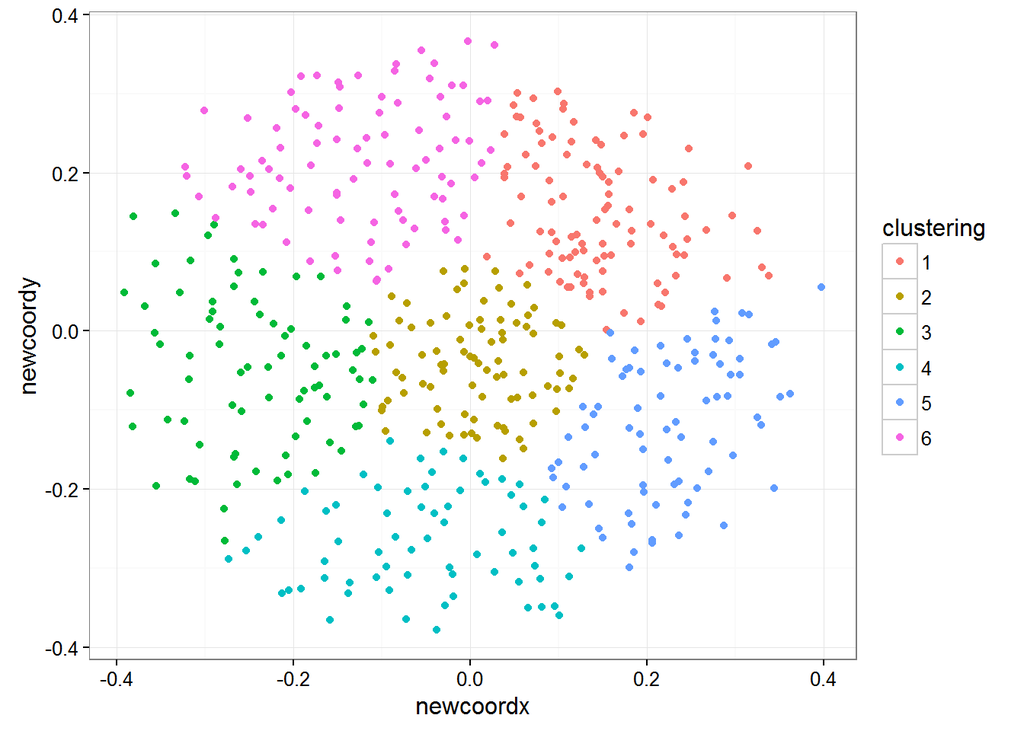

Widzimy że otrzymaliśmy istotnie mniej interesujące grupowanie niż dla stacji. Okazuję się, że odwiedzający są rozłożeniu w przestrzeni bardzo równomiernie i niestety nie można wyodrebnić ciekawych klastrów.

### Porównanie klastrów i stref

Zauważmy, że zastosowane klastrowanie na macierzy odwiedzin prowadzi (przy każdej z metod liczenia odległości) do następującej charakteryzacji: jeśli mamy wybraną stację CNK{X} przypisaną do klastra K(X) to osoby odwiedzające stacje X przeważnie odwiedzają stacje z klastra K(X). Zaciekawiło nas, czy otrzymany w ten sposób podział jest podobny do klasyfikacji tematycznej. Porównamy również rezultaty osięgnięte przy korzystaniu z odległości “jaccard” oraz manhattan“. Do zbadania podobieństwa klastrów użyliśmy zmodyfikowanego indeksu Randa który ma wartość oczekiwaną jeden jeżeli grupowania są identyczne a zero gdy są niezależne.

Zmodyfikowany indeks Randa dla 4-elementowych klastrów opartych na odległości “jaccard” i “manhattan”:

```
## [1] 0.2502076
```

Zmodyfikowany indeks Randa dla 4-elementowych klastrów opartych na: (a) odległości “jaccard” (b) strefach tematycznych:

```
## [1] 0.4320327
```

Zmodyfikowany indeks Randa dla 4-elementowych klastrów opartych na: (a) odległości “manhattan” (b) strefach tematycznych:

```
## [1] 0.3107382
```

Pojawia się interesująca właściwość: otrzymaliśmy większe podobieństwa na polu “klastrowanie oparte na odwiedzinach” versus “klastrowanie oparte o strefy” niż dla dwóch grupowań z wykorystaniem tej samej macierzy odwiedzin i odmienną odległością.

Związek między klastrami na macierzy odwiedzin oraz podziałem tematycznym można też ładnie zilustrować za pomocą map ciepła:

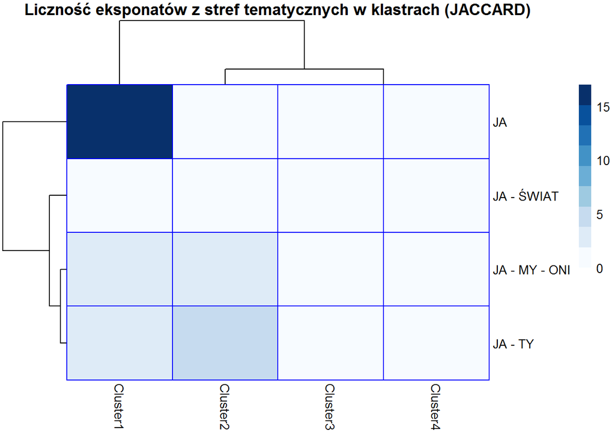

Widzimy mocny związek między strefą “JA” i pierwszym klastrem.

[output not shown]

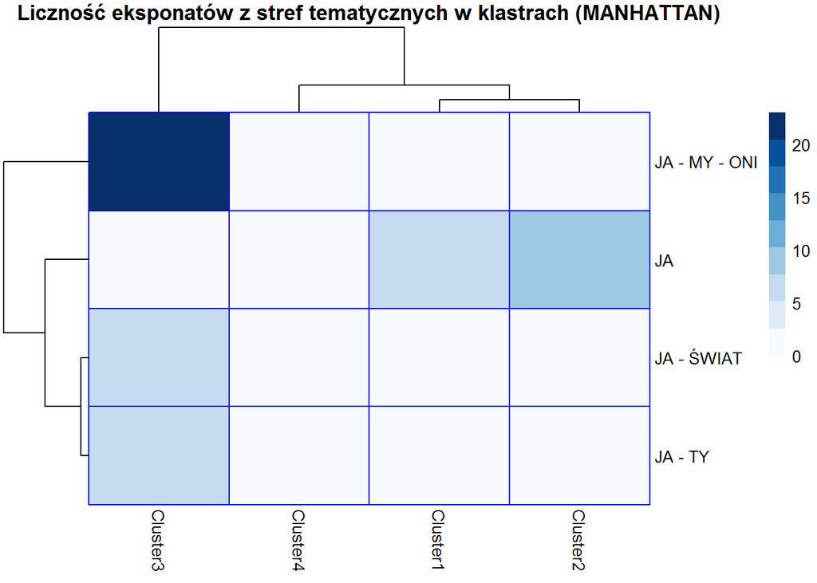

Widzimy mocny związek między strefą “JA-MY-ONI” i trzecim klastrem.

# Podsumowanie

Analiza prowadzi do następujących wniosków:

### Ogólne:

- Rozkład czasu spędzonego przy maszynie wydaje się być zbliżony do rozkładu gamma. Widać jednak, że w okolicach 100 sekund następuje znaczny skok liczby odwiedzających.
- Zauważamy, że najbardziej odwiedzaną stacją było Wejście do sali strachów - cnk19a oraz Wyjście z sali strachów - cnk19b. Innymi często odwiedzanymi eksponatami są: Powąchaj mnie - cnk16, Mózg podczas pracy - cnk02 oraz Kim jesteś - cnk18.
- Można zauważyć, że zdecydowanie najwięcej odwiedzin było w grupie JA.

### Podział odwiedzających:

Gdy dokonamy podziału odwiedzających na trzy grupy w zależności od: - liczby wejść na danej stacji przez odwiedzającego - łącznej liczba czynności na wszystkich eksponatach - średniego czas spędzony na wszystkich odwiedzonych stacjach - liczby odwiedzonych stacji

to otrzymujemy:

a)Czynnikiem rozróżniającym odwiedzających jest głównie liczba interakcji.

c)Stosunkowo niewielka liczba odwiedzających plasuje się powyżej średniego czasu odwiedzin równego 250 sekund.

d)Udział każdej grupy gości wśród odwiedzających poszczególną stacje różni się istotnie w zależności od stacji. Co więcej można zauważyć zależność tej proporcji od podziału na kategorie: JA, JA-MY-ONI, JA-SWIAT, JA-TY

### Reguły przejścia:

- Kluczowym elemetem współodwiedzania jest położenie przestrzenne.
- CNK16 - “Powąchaj mnie” jest stacją zachęcającą do odwiedzenia innych eksponatów

### Podział stacji:

- Istnieją charakterystyczne grupy stacji ze względu na współwystępowanie odwiedzin. Dużo trudniej jest jednak dostrzec analogiczną zależność dla gości. Wyniki pośrednie otrzymane w trakcie badania wskazują, że odpowiedzialne za tą różnice są osoby które w niewielkim stopniu korzystają z możliwości oferowanych przez CNK. Potwierdził się znany fakt, że otrzymane klastrowanie istotnie zależy od wyboru odległości.
- Można zauważyć istotne podobieństwo klasyfikacji stacji w oparciu o “wspólne odwiedzanie” z podziałem na strefy. Wskazuje na to zmodyfikowany indeks Randa (0.4320327 dla odległości liczonej metodą “jaccard”, 0.3107382 dla odległości liczonej metodą “manhattan”). Podobieństwo to jest większe niż gdy rozpatrzymy tą samą bazową macierz odwiedzin i dwie powyższe odległości (zmodyfikowany Rand 0.2502076).